# Peak fitting for XRD pattern from dpp

- Please check setup_for_notebooks file if you have problem using the notebooks in this folder.
- In this notebook, we will learn how to plot XRD patterns using the information saved in `dpp`.
- `dpp` is a project file saved in `PeakPo`. You may plot, jcpds information and cake as well as many other information.

```python
import sys
sys.path.append('../local_modules')
sys.path.append('../../peakpo')
```

## Check the versio of pyFAI in your conda environment

```python
import pyFAI
pyFAI.version
```

```
'0.14.2'
```

Note that the example data files I provided are made with `pyFAI` version `0.14`. If you see version higher than `0.15` here, you will get error when you read the example `dpp` file. In that case, you either follow the instruction in setup_for_notebooks.ipynb or you may use your own dpp for this note book.

## Read dpp

```python
import dill
import numpy as np
```

```python
%ls ../data/hStv/*.dpp
```

```
../data/hStv/hSiO2_404_009.dpp
```

```python
filen_dpp = '../data/hStv/hSiO2_404_009.dpp'
```

```python
with open(filen_dpp, 'rb') as f:
    model_dpp = dill.load(f)
```

## Setup a new PeakPo model and assign info from dpp

```python
from model import PeakPoModel
model = PeakPoModel()
```

Make sure to reset the chi folder location using the `new_chi_path` option.

```python
model.set_from(model_dpp, new_chi_path='../data/hStv')
```

See `xrd_pattern.ipynb` file for basic operations.

## Make a simple plot

The following three modules are all in the `../local_modules` folder.

```python
from xrd_unitconv import * # Make conversios between different x-axis units
```

```python
import quick_plots as quick # A function to plot XRD pattern
import fancy_plots as fancy # A function to plot XRD pattern
```

```python
%matplotlib inline
%config InlineBackend.figure_format = 'retina'
```

```python
import matplotlib.pyplot as plt
```

```
(6.0005517, 20.994111, -49.297263099930205, 2799.9014723947657)
(6.0005517, 20.994111, -2334.2171366494, 2799.9014723947657)
```

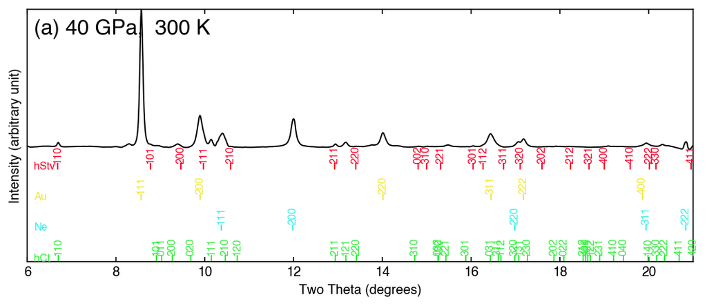

```python
f, ax = plt.subplots(figsize=(9,3.5))
fancy.plot_diffpattern(ax, model)
print(ax.axis())
fancy.plot_jcpds(ax, model, bar_position=0.1, bar_height=5,
           show_index=True,
           phase_names = ['hStv', 'Au', 'Ne', 'hCt'], bar_vsep=5.)
print(ax.axis())
pressure = model.get_saved_pressure()
temperature = model.get_saved_temperature()
ax.text(0.01,0.9, "(a) {0:.0f} GPa, {1: .0f} K".format(pressure, temperature),
        transform = ax.transAxes, fontsize=16)
plt.savefig('test.pdf', bbox_inches='tight')
```

## Choose ROI

Check by changing the `xrange` for `plot_diffpattern`.

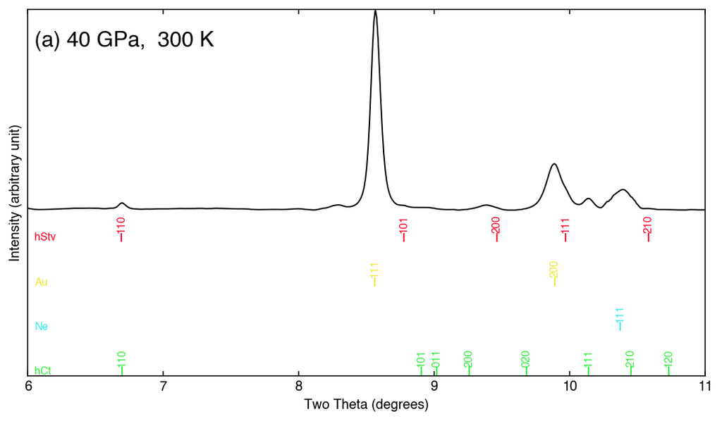

```python
f, ax = plt.subplots(figsize=(9,5))
fancy.plot_diffpattern(ax, model, xrange=[6, 11])
fancy.plot_jcpds(ax, model, bar_position=0.1, bar_height=5,
           show_index=True,
           phase_names = ['hStv', 'Au', 'Ne', 'hCt'], bar_vsep=5.)
pressure = model.get_saved_pressure()
temperature = model.get_saved_temperature()
ax.text(0.01,0.9, "(a) {0:.0f} GPa, {1: .0f} K".format(pressure, temperature),
        transform = ax.transAxes, fontsize=16)
plt.savefig('test.pdf', bbox_inches='tight')
```

Get background subtracted pattern for masking.

```python
x, y = model.base_ptn.get_bgsub()
x
```

```
array([ 6.0005517,  6.0109784,  6.021405 , ..., 20.973258 , 20.983684 ,
       20.994111 ])
```

Masking for ROI

```python
import numpy.ma as ma

x_ma = ma.masked_outside(x, 6., 11.)
x_roi = x_ma.compressed()
y_roi = ma.masked_where(np.ma.getmask(x_ma), y).compressed()
```

Quick plot to check

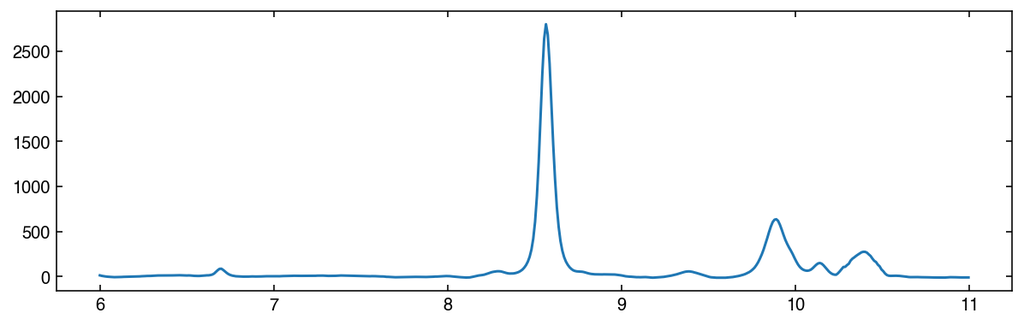

```python
figure = plt.subplots(figsize=(10,3))
plt.plot(x_roi, y_roi)
```

## Setup fitting model

```python
from lmfit.models import PseudoVoigtModel, LinearModel
from lmfit import Parameters
```

## Make initial peak position array

```python
from scipy.signal import find_peaks

peaks, _ = find_peaks(y_roi, height=30.)
peaks
```

```
array([ 67, 220, 246, 325, 373, 397, 421])
```

Plot to see if the search positions are reasonable.

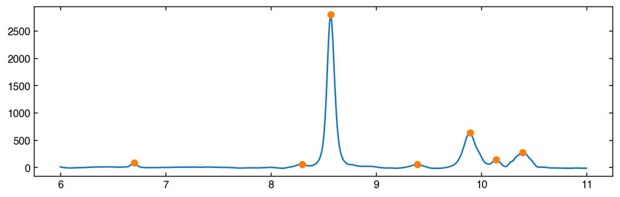

```python
figure = plt.subplots(figsize=(10,3))
plt.plot(x_roi, y_roi)
plt.plot(x_roi[peaks], y_roi[peaks], 'o')
```

## Setup fitting model

```python
from lmfit.models import PseudoVoigtModel, LinearModel
from lmfit import Parameters
```

## Define some functions for peak fitting

Define functions for peakfitting. Here we use `LMFIT` module.

```python
from xrd_pkfit import *
```

## First fitting attempt without any restriction

```python
mod, pars = make_model(x_roi[peaks])
out = mod.fit(y_roi, pars, x=x_roi, fit_kws={'maxfev': 500})
print(out.fit_report(min_correl=0.5))
```

```
[[Model]]
    (((((((Model(linear, prefix='bg_') + Model(pvoigt, prefix='pk0_')) + Model(pvoigt, prefix='pk1_')) + Model(pvoigt, prefix='pk2_')) + Model(pvoigt, prefix='pk3_')) + Model(pvoigt, prefix='pk4_')) + Model(pvoigt, prefix='pk5_')) + Model(pvoigt, prefix='pk6_'))
[[Fit Statistics]]
    # function evals   = 225
    # data points      = 480
    # variables        = 30
    chi-square         = 85049.827
    reduced chi-square = 189.000
    Akaike info crit   = 2545.059
    Bayesian info crit = 2670.273
[[Variables]]
    bg_intercept:    11.7490860 +/- 7.314150 (62.25%) (init= 0)
    bg_slope:       -1.92238746 +/- 0.867763 (45.14%) (init= 0)
    pk0_fraction:    0.99914425 +/- 0.439206 (43.96%) (init= 0)
    pk0_sigma:       0.09905194 +/- 0.022508 (22.72%) (init= 0.05)
    pk0_center:      6.67814455 +/- 0.011066 (0.17%) (init= 6.699139)
    pk0_amplitude:   13.7291342 +/- 3.199312 (23.30%) (init= 1000)
    pk0_fwhm:        0.19810388 +/- 0.043560 (21.99%)  == '2.0000000*pk0_sigma'
    pk1_fraction:    0.71390507 +/- 1.440882 (201.83%) (init= 0)
    pk1_sigma:       0.04899342 +/- 0.022649 (46.23%) (init= 0.05)
    pk1_center:      8.27232961 +/- 0.013928 (0.17%) (init= 8.29442)
    pk1_amplitude:   1.94815516 +/- 1.650007 (84.70%) (init= 1000)
    pk1_fwhm:        0.09798684 +/- 0.045272 (46.20%)  == '2.0000000*pk1_sigma'
    pk2_fraction:    0.53578175 +/- 0.013639 (2.55%) (init= 0)
    pk2_sigma:       0.04131704 +/- 0.000178 (0.43%) (init= 0.05)
    pk2_center:      8.56763923 +/- 0.000107 (0.00%) (init= 8.565514)
    pk2_amplitude:   298.762770 +/- 1.505359 (0.50%) (init= 1000)
    pk2_fwhm:        0.08263408 +/- 0.000352 (0.43%)  == '2.0000000*pk2_sigma'
    pk3_fraction:    0.01241608 +/- 5.77e+05 (4647278978.67%) (init= 0)
    pk3_sigma:       9.6370e-05 +/- 0.473812 (491658.24%) (init= 0.05)
    pk3_center:      9.39347570 +/- 0.004071 (0.04%) (init= 9.389221)
    pk3_amplitude:   22.7444443 +/- 1.28e+07 (56470649.79%) (init= 1000)
    pk3_fwhm:        0.00019274 +/- 0.947947 (491825.72%)  == '2.0000000*pk3_sigma'
    pk4_fraction:    0.42273441 +/- 0.060602 (14.34%) (init= 0)
    pk4_sigma:       0.07398460 +/- 0.001004 (1.36%) (init= 0.05)
    pk4_center:      9.89043232 +/- 0.000654 (0.01%) (init= 9.889702)
    pk4_amplitude:   114.039270 +/- 2.756552 (2.42%) (init= 1000)
    pk4_fwhm:        0.14796921 +/- 0.001722 (1.16%)  == '2.0000000*pk4_sigma'
    pk5_fraction:    0.99989658 +/- 0.227448 (22.75%) (init= 0)
    pk5_sigma:       0.03301947 +/- 0.003775 (11.43%) (init= 0.05)
```

[output cut: 16 more lines]

```
    C(pk0_fraction, pk0_amplitude)  =  0.701
    C(bg_intercept, pk0_amplitude)  = -0.694
    C(pk5_fraction, pk5_amplitude)  =  0.689
    C(bg_slope, pk6_amplitude)   = -0.616
    C(bg_slope, pk0_amplitude)   =  0.613
    C(pk5_amplitude, pk6_amplitude)  = -0.589
    C(pk2_fraction, pk2_sigma)   = -0.589
    C(pk4_amplitude, pk5_amplitude)  = -0.584
    C(pk1_fraction, pk1_sigma)   = -0.566
    C(bg_slope, pk6_fraction)    = -0.554
    C(pk5_amplitude, pk6_fraction)  = -0.545
    C(bg_intercept, pk6_amplitude)  =  0.544
    C(pk0_fraction, pk0_sigma)   = -0.539
    C(pk4_fraction, pk5_amplitude)  = -0.525
    C(pk5_fraction, pk5_sigma)   = -0.525
```

Plot the fitting results

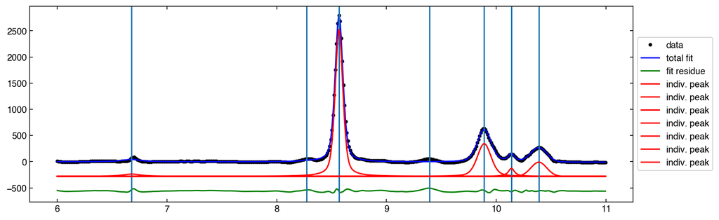

```python
n_peaks = len(x_roi[peaks])
figure, ax = plt.subplots(figsize=(12,4))
plot_fitresult(ax, x_roi, y_roi, out, n_peaks)
```

## Do better initial guess

Pereform new fitting

```python
mod, pars = make_model(x_roi[peaks], fwhm=0.03, amplitude=100.)
out = mod.fit(y_roi, pars, x=x_roi, fit_kws={'maxfev': 500})
print(out.fit_report(min_correl=0.5))
```

```
[[Model]]
    (((((((Model(linear, prefix='bg_') + Model(pvoigt, prefix='pk0_')) + Model(pvoigt, prefix='pk1_')) + Model(pvoigt, prefix='pk2_')) + Model(pvoigt, prefix='pk3_')) + Model(pvoigt, prefix='pk4_')) + Model(pvoigt, prefix='pk5_')) + Model(pvoigt, prefix='pk6_'))
[[Fit Statistics]]
    # function evals   = 189
    # data points      = 480
    # variables        = 30
    chi-square         = 60700.902
    reduced chi-square = 134.891
    Akaike info crit   = 2383.165
    Bayesian info crit = 2508.379
[[Variables]]
    bg_intercept:    29.1722806 +/- 4.995923 (17.13%) (init= 0)
    bg_slope:       -3.83526210 +/- 0.645062 (16.82%) (init= 0)
    pk0_fraction:    0.51590945 +/- 0.431690 (83.68%) (init= 0)
    pk0_sigma:       0.03063716 +/- 0.004060 (13.25%) (init= 0.03)
    pk0_center:      6.69518915 +/- 0.002586 (0.04%) (init= 6.699139)
    pk0_amplitude:   6.55216766 +/- 1.023892 (15.63%) (init= 100)
    pk0_fwhm:        0.06127433 +/- 0.008120 (13.25%)  == '2.0000000*pk0_sigma'
    pk1_fraction:    0.59988174 +/- 0.807284 (134.57%) (init= 0)
    pk1_sigma:       0.06145041 +/- 0.008172 (13.30%) (init= 0.03)
    pk1_center:      8.27073401 +/- 0.005765 (0.07%) (init= 8.29442)
    pk1_amplitude:   4.56442997 +/- 1.489646 (32.64%) (init= 100)
    pk1_fwhm:        0.12290083 +/- 0.016344 (13.30%)  == '2.0000000*pk1_sigma'
    pk2_fraction:    0.55998216 +/- 0.011321 (2.02%) (init= 0)
    pk2_sigma:       0.04126828 +/- 0.000146 (0.35%) (init= 0.03)
    pk2_center:      8.56758351 +/- 9.03e-05 (0.00%) (init= 8.565514)
    pk2_amplitude:   302.091134 +/- 1.270450 (0.42%) (init= 100)
    pk2_fwhm:        0.08253656 +/- 0.000292 (0.35%)  == '2.0000000*pk2_sigma'
    pk3_fraction:    0.73052766 +/- 0.365205 (49.99%) (init= 0)
    pk3_sigma:       0.06668190 +/- 0.007879 (11.82%) (init= 0.03)
    pk3_center:      9.37829233 +/- 0.003947 (0.04%) (init= 9.389221)
    pk3_amplitude:   6.70558552 +/- 1.220807 (18.21%) (init= 100)
    pk3_fwhm:        0.13336381 +/- 0.015759 (11.82%)  == '2.0000000*pk3_sigma'
    pk4_fraction:    0.31530220 +/- 0.059561 (18.89%) (init= 0)
    pk4_sigma:       0.07496412 +/- 0.000848 (1.13%) (init= 0.03)
    pk4_center:      9.89032617 +/- 0.000578 (0.01%) (init= 9.889702)
    pk4_amplitude:   110.329860 +/- 2.513495 (2.28%) (init= 100)
    pk4_fwhm:        0.14992825 +/- 0.001695 (1.13%)  == '2.0000000*pk4_sigma'
    pk5_fraction:    0.98649024 +/- 0.219909 (22.29%) (init= 0)
    pk5_sigma:       0.04167542 +/- 0.003769 (9.05%) (init= 0.03)
```

[output cut: 13 more lines]

```
    C(pk0_fraction, pk0_amplitude)  =  0.821
    C(pk2_fraction, pk2_amplitude)  =  0.819
    C(pk5_fraction, pk5_amplitude)  =  0.772
    C(bg_slope, pk6_amplitude)   = -0.659
    C(pk3_fraction, pk3_sigma)   = -0.654
    C(pk4_amplitude, pk5_amplitude)  = -0.638
    C(pk3_fraction, pk3_amplitude)  =  0.616
    C(bg_intercept, pk6_amplitude)  =  0.595
    C(bg_slope, pk6_fraction)    = -0.594
    C(pk5_amplitude, pk6_amplitude)  = -0.581
    C(pk2_fraction, pk2_sigma)   = -0.560
    C(pk0_fraction, pk0_sigma)   = -0.555
    C(bg_intercept, pk6_fraction)  =  0.536
    C(pk4_fraction, pk5_amplitude)  = -0.514
    C(pk1_fraction, pk1_sigma)   = -0.511
```

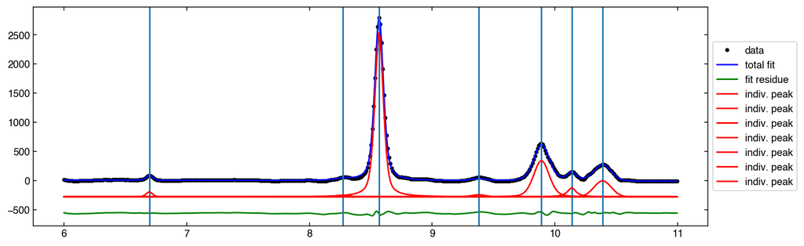

```python
n_peaks = len(x_roi[peaks])
figure, ax = plt.subplots(figsize=(12,4))
plot_fitresult(ax, x_roi, y_roi, out, n_peaks)
```

## Use the last fitting results for the next fitting

```python
pars_new = out.params
```

```python
out = mod.fit(y_roi, pars_new, x=x_roi, fit_kws={'maxfev': 500})
print(out.fit_report(min_correl=0.5))
```

```
[[Model]]
    (((((((Model(linear, prefix='bg_') + Model(pvoigt, prefix='pk0_')) + Model(pvoigt, prefix='pk1_')) + Model(pvoigt, prefix='pk2_')) + Model(pvoigt, prefix='pk3_')) + Model(pvoigt, prefix='pk4_')) + Model(pvoigt, prefix='pk5_')) + Model(pvoigt, prefix='pk6_'))
[[Fit Statistics]]
    # function evals   = 503
    # data points      = 480
    # variables        = 30
    chi-square         = 47779.818
    reduced chi-square = 106.177
    Akaike info crit   = 2268.275
    Bayesian info crit = 2393.488
[[Variables]]
    bg_intercept:    28.3283335 +/- 4.486009 (15.84%) (init= 29.17228)
    bg_slope:       -3.99541920 +/- 0.582845 (14.59%) (init=-3.835262)
    pk0_fraction:    0.74671887 +/- 0.313435 (41.97%) (init= 0.5159095)
    pk0_sigma:       0.03050200 +/- 0.004038 (13.24%) (init= 0.03063717)
    pk0_center:      6.69504203 +/- 0.002299 (0.03%) (init= 6.695189)
    pk0_amplitude:   7.39223915 +/- 0.896851 (12.13%) (init= 6.552168)
    pk0_fwhm:        0.06100400 +/- 0.008076 (13.24%)  == '2.0000000*pk0_sigma'
    pk1_fraction:    0.00473684 +/- 0.983531 (20763.43%) (init= 0.5998817)
    pk1_sigma:       0.04023895 +/- 0.007253 (18.03%) (init= 0.06145042)
    pk1_center:      8.27500294 +/- 0.005252 (0.06%) (init= 8.270734)
    pk1_amplitude:   3.38135714 +/- 1.077574 (31.87%) (init= 4.56443)
    pk1_fwhm:        0.08047791 +/- 0.014507 (18.03%)  == '2.0000000*pk1_sigma'
    pk2_fraction:    0.53523776 +/- 0.009813 (1.83%) (init= 0.5599822)
    pk2_sigma:       0.04133250 +/- 0.000128 (0.31%) (init= 0.04126828)
    pk2_center:      8.56765135 +/- 7.99e-05 (0.00%) (init= 8.567584)
    pk2_amplitude:   298.846896 +/- 1.093183 (0.37%) (init= 302.0911)
    pk2_fwhm:        0.08266501 +/- 0.000256 (0.31%)  == '2.0000000*pk2_sigma'
    pk3_fraction:    1.2819e-09 +/- 0.575693 (44910663219.10%) (init= 0.7305277)
    pk3_sigma:       0.06052691 +/- 0.005850 (9.67%) (init= 0.06668191)
    pk3_center:      9.38425335 +/- 0.004238 (0.05%) (init= 9.378292)
    pk3_amplitude:   7.71940342 +/- 1.508313 (19.54%) (init= 6.705586)
    pk3_fwhm:        0.12105382 +/- 0.011701 (9.67%)  == '2.0000000*pk3_sigma'
    pk4_fraction:    0.33341226 +/- 0.051429 (15.43%) (init= 0.3153022)
    pk4_sigma:       0.07516648 +/- 0.000753 (1.00%) (init= 0.07496413)
    pk4_center:      9.89032149 +/- 0.000512 (0.01%) (init= 9.890326)
    pk4_amplitude:   111.694162 +/- 2.284480 (2.05%) (init= 110.3299)
    pk4_fwhm:        0.15033296 +/- 0.001505 (1.00%)  == '2.0000000*pk4_sigma'
    pk5_fraction:    0.96950193 +/- 0.178592 (18.42%) (init= 0.9864902)
    pk5_sigma:       0.04213893 +/- 0.003350 (7.95%) (init= 0.04167543)
```

[output cut: 12 more lines]

```
    C(pk4_fraction, pk4_amplitude)  =  0.909
    C(pk1_fraction, pk1_amplitude)  =  0.900
    C(pk2_fraction, pk2_amplitude)  =  0.819
    C(pk5_fraction, pk5_amplitude)  =  0.745
    C(pk0_fraction, pk0_amplitude)  =  0.735
    C(bg_slope, pk6_amplitude)   = -0.670
    C(pk4_amplitude, pk5_amplitude)  = -0.641
    C(pk0_fraction, pk0_sigma)   = -0.609
    C(bg_intercept, pk6_amplitude)  =  0.608
    C(bg_slope, pk6_fraction)    = -0.608
    C(pk2_fraction, pk2_sigma)   = -0.564
    C(pk5_amplitude, pk6_amplitude)  = -0.552
    C(bg_intercept, pk6_fraction)  =  0.552
    C(pk4_fraction, pk5_amplitude)  = -0.522
    C(pk1_fraction, pk1_sigma)   = -0.502
```

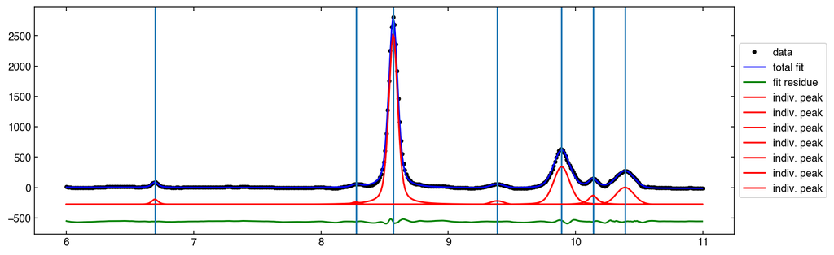

```python
n_peaks = len(x_roi[peaks])
figure, ax = plt.subplots(figsize=(12,4))
plot_fitresult(ax, x_roi, y_roi, out, n_peaks)
```

## Fix some parameters for fitting

```python
pars_new = out.params
pars_new
```

```
Parameters([('bg_intercept',
             <Parameter 'bg_intercept', value=28.32833357262428 +/- 4.49, bounds=[-inf:inf]>),
            ('bg_slope',
             <Parameter 'bg_slope', value=-3.9954192033102194 +/- 0.583, bounds=[-inf:inf]>),
            ('pk0_fraction',
             <Parameter 'pk0_fraction', value=0.746718872944975 +/- 0.313, bounds=[0.0:1.0]>),
            ('pk0_sigma',
             <Parameter 'pk0_sigma', value=0.030502000098484028 +/- 0.00404, bounds=[0.0:0.5]>),
            ('pk0_center',
             <Parameter 'pk0_center', value=6.6950420336582175 +/- 0.0023, bounds=[6.1991389:7.1991389]>),
            ('pk0_amplitude',
             <Parameter 'pk0_amplitude', value=7.392239151294238 +/- 0.897, bounds=[0.0:inf]>),
            ('pk0_fwhm',
             <Parameter 'pk0_fwhm', value=0.061004000196968056 +/- 0.00808, bounds=[-inf:inf], expr='2.0000000*pk0_sigma'>),
            ('pk1_fraction',
             <Parameter 'pk1_fraction', value=0.0047368437901394445 +/- 0.984, bounds=[0.0:1.0]>),
            ('pk1_sigma',
             <Parameter 'pk1_sigma', value=0.040238957993689484 +/- 0.00725, bounds=[0.0:0.5]>),
            ('pk1_center',
             <Parameter 'pk1_center', value=8.275002942079906 +/- 0.00525, bounds=[7.7944203000000005:8.7944203]>),
            ('pk1_amplitude',
             <Parameter 'pk1_amplitude', value=3.3813571421224795 +/- 1.08, bounds=[0.0:inf]>),
            ('pk1_fwhm',
             <Parameter 'pk1_fwhm', value=0.08047791598737897 +/- 0.0145, bounds=[-inf:inf], expr='2.0000000*pk1_sigma'>),
            ('pk2_fraction',
             <Parameter 'pk2_fraction', value=0.5352377607277863 +/- 0.00981, bounds=[0.0:1.0]>),
            ('pk2_sigma',
             <Parameter 'pk2_sigma', value=0.0413325079572846 +/- 0.000128, bounds=[0.0:0.5]>),
            ('pk2_center',
             <Parameter 'pk2_center', value=8.567651349923386 +/- 7.99e-05, bounds=[8.0655138:9.0655138]>),
            ('pk2_amplitude',
             <Parameter 'pk2_amplitude', value=298.84689642751647 +/- 1.09, bounds=[0.0:inf]>),
            ('pk2_fwhm',
             <Parameter 'pk2_fwhm', value=0.0826650159145692 +/- 0.000256, bounds=[-inf:inf], expr='2.0000000*pk2_sigma'>),
            ('pk3_fraction',
             <Parameter 'pk3_fraction', value=1.2818636707656594e-09 +/- 0.576, bounds=[0.0:1.0]>),
            ('pk3_sigma',
             <Parameter 'pk3_sigma', value=0.060526913876875005 +/- 0.00585, bounds=[0.0:0.5]>),
            ('pk3_center',
             <Parameter 'pk3_center', value=9.384253358157784 +/- 0.00424, bounds=[8.8892212:9.8892212]>),
```

[output cut: 19 more lines]

```
             <Parameter 'pk5_center', value=10.137025962124882 +/- 0.00172, bounds=[9.639942:10.639942]>),
            ('pk5_amplitude',
             <Parameter 'pk5_amplitude', value=19.46889654226545 +/- 1.89, bounds=[0.0:inf]>),
            ('pk5_fwhm',
             <Parameter 'pk5_fwhm', value=0.08427786081682104 +/- 0.0067, bounds=[-inf:inf], expr='2.0000000*pk5_sigma'>),
            ('pk6_fraction',
             <Parameter 'pk6_fraction', value=0.089369250814746 +/- 0.146, bounds=[0.0:1.0]>),
            ('pk6_sigma',
             <Parameter 'pk6_sigma', value=0.08243764124151592 +/- 0.0016, bounds=[0.0:0.5]>),
            ('pk6_center',
             <Parameter 'pk6_center', value=10.388487314912071 +/- 0.00117, bounds=[9.890182:10.890182]>),
            ('pk6_amplitude',
             <Parameter 'pk6_amplitude', value=50.74400090246448 +/- 2.86, bounds=[0.0:inf]>),
            ('pk6_fwhm',
             <Parameter 'pk6_fwhm', value=0.16487528248303185 +/- 0.0032, bounds=[-inf:inf], expr='2.0000000*pk6_sigma'>)])
```

```python
pars_new['pk1_center'].set(min=8.3, max=8.4, vary=True)
pars_new['pk1_amplitude'].set(1000., vary=True)
```

```python
out = mod.fit(y_roi, pars_new, x=x_roi, fit_kws={'maxfev': 500})
print(out.fit_report(min_correl=0.5))
```

```
[[Model]]
    (((((((Model(linear, prefix='bg_') + Model(pvoigt, prefix='pk0_')) + Model(pvoigt, prefix='pk1_')) + Model(pvoigt, prefix='pk2_')) + Model(pvoigt, prefix='pk3_')) + Model(pvoigt, prefix='pk4_')) + Model(pvoigt, prefix='pk5_')) + Model(pvoigt, prefix='pk6_'))
[[Fit Statistics]]
    # function evals   = 510
    # data points      = 480
    # variables        = 30
    chi-square         = 50433.257
    reduced chi-square = 112.074
    Akaike info crit   = 2294.218
    Bayesian info crit = 2419.431
[[Variables]]
    bg_intercept:    23.8937712 +/- 0        (0.00%) (init= 28.32833)
    bg_slope:       -3.43395798 +/- 0        (0.00%) (init=-3.995419)
    pk0_fraction:    0.81497275 +/- 0        (0.00%) (init= 0.7467189)
    pk0_sigma:       0.03062433 +/- 0        (0.00%) (init= 0.030502)
    pk0_center:      6.69497495 +/- 0        (0.00%) (init= 6.695042)
    pk0_amplitude:   7.71600697 +/- 0        (0.00%) (init= 7.392239)
    pk0_fwhm:        0.06124866 +/- 0        (0.00%)  == '2.0000000*pk0_sigma'
    pk1_fraction:    0.00415563 +/- 0        (0.00%) (init= 0.004736844)
    pk1_sigma:       0.04028962 +/- 0        (0.00%) (init= 0.04023896)
    pk1_center:      8.30000000 +/- 0        (0.00%) (init= 8.3)
    pk1_amplitude:   2.92514518 +/- 0        (0.00%) (init= 1000)
    pk1_fwhm:        0.08057924 +/- 0        (0.00%)  == '2.0000000*pk1_sigma'
    pk2_fraction:    0.53241065 +/- 0        (0.00%) (init= 0.5352378)
    pk2_sigma:       0.04134291 +/- 0        (0.00%) (init= 0.04133251)
    pk2_center:      8.56765142 +/- 0        (0.00%) (init= 8.567651)
    pk2_amplitude:   298.492876 +/- 0        (0.00%) (init= 298.8469)
    pk2_fwhm:        0.08268582 +/- 0        (0.00%)  == '2.0000000*pk2_sigma'
    pk3_fraction:    0.00071570 +/- 0        (0.00%) (init= 1.281864e-09)
    pk3_sigma:       0.05922553 +/- 0        (0.00%) (init= 0.06052691)
    pk3_center:      9.38410655 +/- 0        (0.00%) (init= 9.384253)
    pk3_amplitude:   7.42227692 +/- 0        (0.00%) (init= 7.719403)
    pk3_fwhm:        0.11845107 +/- 0        (0.00%)  == '2.0000000*pk3_sigma'
    pk4_fraction:    0.37237975 +/- 0        (0.00%) (init= 0.3334123)
    pk4_sigma:       0.07485621 +/- 0        (0.00%) (init= 0.07516648)
    pk4_center:      9.89045474 +/- 0        (0.00%) (init= 9.890321)
    pk4_amplitude:   113.124270 +/- 0        (0.00%) (init= 111.6942)
    pk4_fwhm:        0.14971242 +/- 0        (0.00%)  == '2.0000000*pk4_sigma'
    pk5_fraction:    0.88984288 +/- 0        (0.00%) (init= 0.9695019)
    pk5_sigma:       0.04142481 +/- 0        (0.00%) (init= 0.04213893)
    pk5_center:      10.1375474 +/- 0        (0.00%) (init= 10.13703)
    pk5_amplitude:   18.2814904 +/- 0        (0.00%) (init= 19.4689)
    pk5_fwhm:        0.08284962 +/- 0        (0.00%)  == '2.0000000*pk5_sigma'
    pk6_fraction:    0.01367158 +/- 0        (0.00%) (init= 0.08936925)
    pk6_sigma:       0.08278052 +/- 0        (0.00%) (init= 0.08243764)
    pk6_center:      10.3882145 +/- 0        (0.00%) (init= 10.38849)
    pk6_amplitude:   49.3175883 +/- 0        (0.00%) (init= 50.744)
    pk6_fwhm:        0.16556104 +/- 0        (0.00%)  == '2.0000000*pk6_sigma'
```

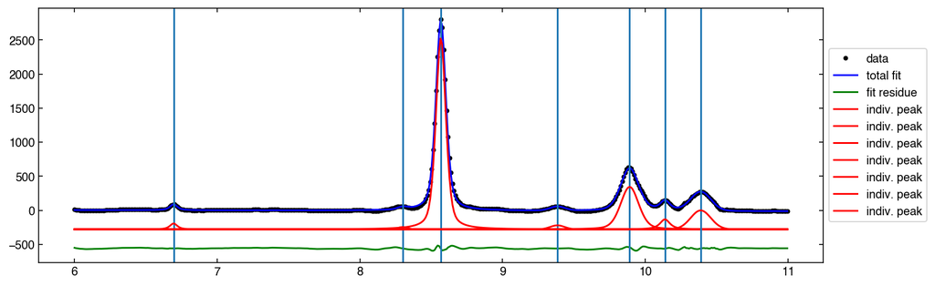

```python
n_peaks = len(peaks)
figure, ax = plt.subplots(figsize=(12,4))
plot_fitresult(ax, x_roi, y_roi, out, n_peaks)
```